# Week 7 Homework

Author: Laura Wooten

Last update: 20 May, 2025

> Q1: 25 points Discuss cross validation and describe how to partition data for cross validation and the potential issues that may occur.

Cross validation is an external validation technique used to evaluate how well a regression model performs on new, unseen data. This is important because, while we may have learned how to fit a regression model to our dataset, we often use the entire dataset (filtered to the variables of interest) for training. As a result, the model has already used/seen all available data, leaving no separate subset to test for overfitting or to assess how well the model generalizes. Often when we build a regression model on observed data the purpose is to then use it for unknown data, to predict the result of the dependent variable based on new inputs of the independent variables (gene expression).

To ensure the model is robust, not overfitting to outliers or noise, and consistent in its predictions, we can use cross validation. This involves splitting the data into several equally sized (or nearly equal) groups. The model is trained on a subset of these groups while keeping one or more hidden from the training process. The hidden groups are then used to test the model’s performance. Since we know the actual values of both the independent and dependent variables in the test group, we can compare them to the model’s predictions. The differences between predicted and actual values are used to calculate errors, which are then squared and averaged to compute the mean squared error which is a metric of model performance. A lower MSE indicates better generalization to new data.

The top issues I found that could arise with cross validation stems from imbalanced data and data leakage. Imbalances in the data set could be seen as one categorical variable or label appears much more often than the others, therefore the partitioned groups for training may not include enough examples of the less common category or any at all. This could make the model seem more accurate than it actually is because it could learn to always predict the majority category and still get a good MSE. Data leakage occurs when the information set aside in the testing group is used to train the model. Even if the data has been partitioned, data leakage can occur if normalization and feature selection are applied to the entire data set before partitioning for cross validation. This happens because calculations such as the mean and standard deviation for normalization, or identifying the most predictive features are based on all the data, including the portions that will later serve as test groups of data. As a result, even though the model hasn’t been trained yet, it still benefits from information that comes from the test data.

```r
#split data set into 5 groups

n.xval <- 5
s2.xval <- numeric(n.xval)
genes.xval <- character(n.xval)
set.seed(12)
dmatrix <- cbind(rep(1, length(dfs_time)), dfs_time)
xval.grps <- sample((1:dim(eData_filtered)[2])%%n.xval+1)
for (i.xval in 1:n.xval){
  # For training groups - fit linear model:
  exprs.train <- eData_filtered[,xval.grps!=i.xval] # eData of training set
  dmatrix.train <- dmatrix[xval.grps!=i.xval,]
  dfs.fit.train <- lmFit(exprs.train, dmatrix.train)
  # best gene for this iteration
  best.gene <- rownames(topTable(eBayes(dfs.fit.train), coef = "dfs_time"))[1]
  genes.xval[i.xval] <- best.gene

  tmp.df <- data.frame(G=eData_filtered[best.gene,], DFST=dfs_time)
  lm.xval <- lm(DFST~G, tmp.df[xval.grps!=i.xval,])

  test.pred <- predict(lm.xval, tmp.df[xval.grps==i.xval,])
  s2.xval[i.xval] <- mean((test.pred-tmp.df[xval.grps==i.xval, "DFST"])^2)
}
```

The code above is modified from question 3 shows how the partitioned data is assigned to the selected number of groups/folds we choose to conduct the cross validation. `sample((1:dim(eData_filtered)[2])%%n.xval+1))` can be split into the following:  
`1:dim(eData_filtered)[2]` creates a sequence of numbers between 1 and the number of columns in the data frame (representing samples).  
`%%n.xval+1` uses the modello operator to divide each number in the sequence by our number of groups (5) and store the remainder. So now our sequence is a equal proportions of numbers 1-5 (as equal as possible depending on the number of samples)  
`sample()` then permutes (shuffles) the sequence of 1-5’s so that xval.grps is a vector of the same length of the number of samples but the contain a random ordering of numbers 1-5. The index of each group number in xval.grps will correspond to the index of the samples in our expression data, and each sample will be assigned to a group based on the value of the xval.grps at that same index.

In the for loop we iterate across the number of groups we have selected, and assign the expression data for all groups except the current group as the training set of data for the model. Once the model has been made, we use the training data to find the best fit gene according to the model, then use the test set of expression data (the current i.xval) to predict the dependent values according to the same model. This loops runs 5 times, meaning that each fold/group of data has the opportunity of being the test data once each. We can then extract our residual variance from each loop and calculate the mean which will be our MSE, depicting how well our model is able to generalize the training data, and how it responds to new input.  
See below for visualization - Each bar shows the mean squared error for that fold, and the gene labels show which gene was selected as the top predictor for each. Based on this plot, the linear model for 202737_s_at has the lowest s2, therefore the model better generalizes the data.

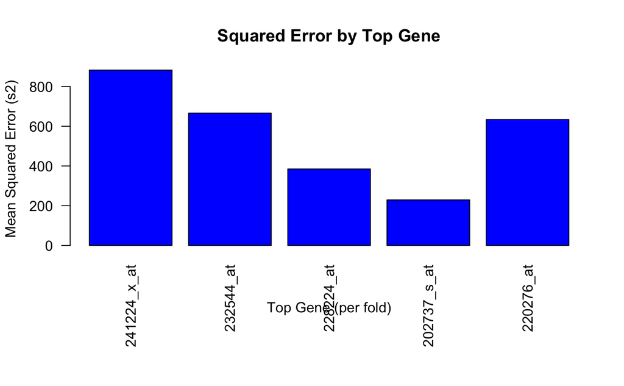

```r
old_par <- par(no.readonly = TRUE)

par(mar = c(8, 4, 4, 2) + 0.1)
barplot(
  s2.xval, names.arg = genes.xval,
  las = 2, col = "blue",
  main = "Squared Error by Top Gene",
  ylab = "Mean Squared Error (s2)",
  xlab = "Top Gene (per fold)"
)

par(old_par) # Restore original settings
```

> Q2: 25 points Download a data set from GEO and find the feature that has the greatest predictive value for an outcome.

**Download data & check for normalization**

```r
library(GEOquery)
geodata <- getGEO("GSE14333", GSEMatrix = TRUE)[[1]]
eData <- exprs(geodata)
pheno <- pData(geodata)

save(eData, file = "GSE14333_exprs.Rda")
save(pheno, file = "GSE14333_pData.Rda")
```

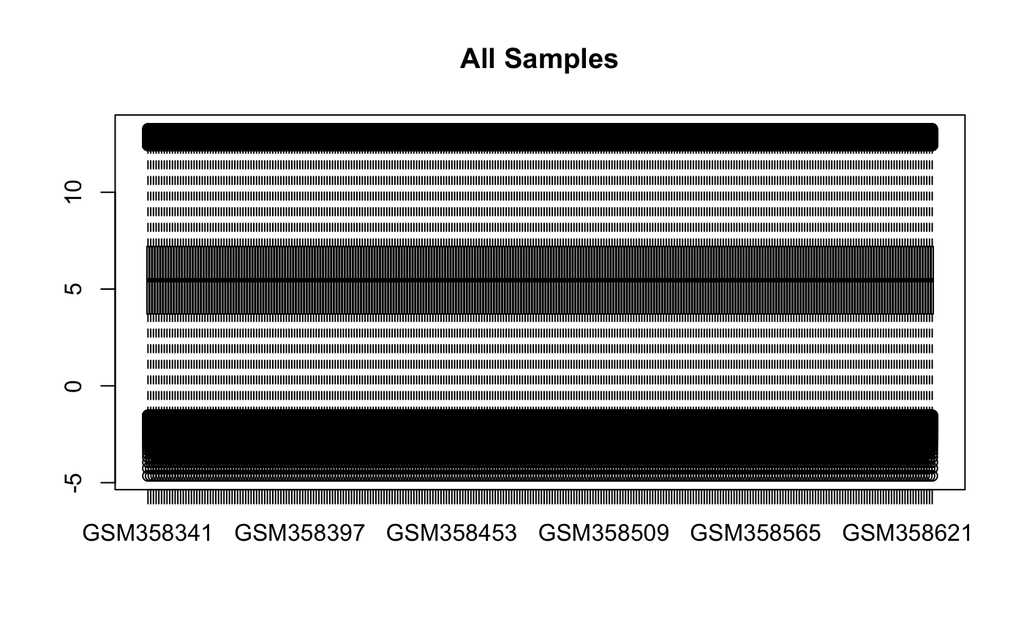

```r
#Since array - visualize normalization with box plots
boxplot(eData, main = "All Samples")

#too crowded, boxplot first 30, plot sample medians and varainces
sample_med <- apply(eData, 2, median)
sample_var <- apply(eData, 2, var)

oldpar <- par(mfrow = c(1, 2))
```

```r
#first 30 samples
boxplot(eData[, 1:30], main = "First 30 Samples")
# plot med/var of all samples
plot(sample_med, type = "b", col = "blue", ylab = "Value", xlab = "Sample",
     main = "Sample Medians and Variances")
```

```r
lines(sample_var, type = "b", col = "red")
legend("topright", legend = c("Median", "Variance"),
       col = c("blue", "red"), lty = 1, pch = 1)
```

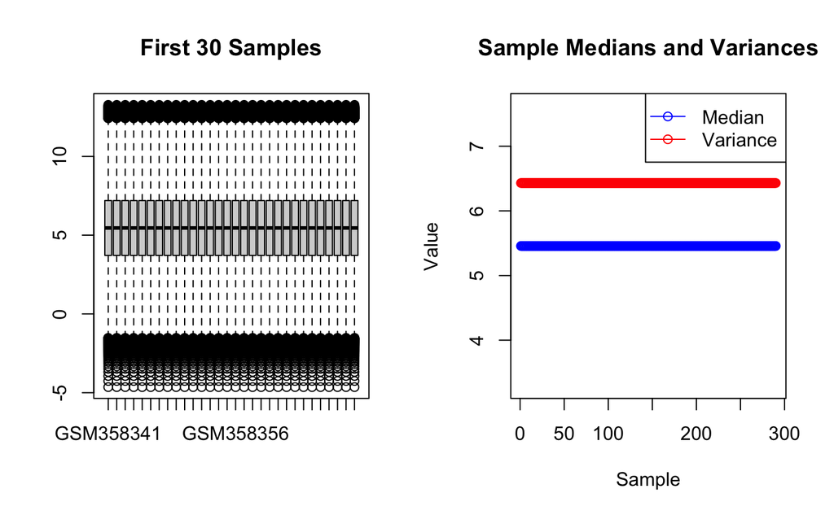

```r
par(oldpar)
```

**Data is normalized**  
The box plot of all 290 samples is very crowded, although you can see a uniform distribution of data, its not very clear. I went ahead to then perform box plots of the first 30 samples, we can see their distributions are all uniform, and I also calculated the median and variance of every sample and plotted them. We can see that the medians and variances are also uniform across samples, therefore this data set is very well normalized.

**Predictive outcome vs association**  
These are different concepts, I began looking at association - then realized the gene with the greatest association doesn’t necessarily mean it has the greatest predictive outcome. I kept both sets of code so that I could compare.  
**Find gene with greatest association for survival time**

```r
#all patient characteristics in one column, separate Disease Free Survival Time, and Censored into new columns, select only non-censored rows b/c for censored cases the true event time is unknown and and will affect the analysis.

#extract & create new column for DFS_Time and DFS_Cens
pheno$DFS_Time <- as.numeric(sub(".*DFS_Time: ([^;]+);.*", "\\1", pheno$characteristics_ch1))
```

[output not shown]

```r
pheno$DFS_Cens <- as.numeric(sub(".*DFS_Cens: ([^;]+);.*", "\\1", pheno$characteristics_ch1))
```

[output not shown]

Warning: NAs introduced by coercion –> does this mean that they are not all labeled the same? Lets check it out.

```r
#find where NA's have been added in, check original pheno$characteristics_ch1 to see what they look like.
cens.na.idx <- is.na(pheno$DFS_Cens)
time.na.idx <- is.na(pheno$DFS_Time)
#are they on the same rows?
identical(cens.na.idx, time.na.idx)
```

```
[1] TRUE
```

```r
#yes, lets see what they look like in the original pData
pheno$characteristics_ch1[cens.na.idx][1:15]#originals aren't labeled differently - just NA. Will exclude from analysis.
```

```
 [1] "Location: Right; DukesStage: A; Age_Diag: 75; Gender: M; DFS_Time: NA; DFS_Cens: NA; AdjXRT: N; AdjCTX: N"
 [2] "Location: Left; DukesStage: A; Age_Diag: 60; Gender: M; DFS_Time: NA; DFS_Cens: NA; AdjXRT: N; AdjCTX: N"
 [3] "Location: Left; DukesStage: A; Age_Diag: 75; Gender: M; DFS_Time: NA; DFS_Cens: NA; AdjXRT: N; AdjCTX: N"
 [4] "Location: Rectum; DukesStage: D; Age_Diag: 69; Gender: M; DFS_Time: NA; DFS_Cens: NA; AdjXRT: N; AdjCTX: N"
 [5] "Location: Left; DukesStage: D; Age_Diag: 73; Gender: M; DFS_Time: NA; DFS_Cens: NA; AdjXRT: Y; AdjCTX: Y"
 [6] "Location: Left; DukesStage: D; Age_Diag: 66; Gender: M; DFS_Time: NA; DFS_Cens: NA; AdjXRT: N; AdjCTX: Y"
 [7] "Location: Left; DukesStage: D; Age_Diag: 63; Gender: F; DFS_Time: NA; DFS_Cens: NA; AdjXRT: N; AdjCTX: N"
 [8] "Location: Left; DukesStage: D; Age_Diag: 54; Gender: M; DFS_Time: NA; DFS_Cens: NA; AdjXRT: N; AdjCTX: Y"
 [9] "Location: Right; DukesStage: D; Age_Diag: 88; Gender: M; DFS_Time: NA; DFS_Cens: NA; AdjXRT: N; AdjCTX: N"
[10] "Location: Left; DukesStage: D; Age_Diag: 58; Gender: M; DFS_Time: NA; DFS_Cens: NA; AdjXRT: N; AdjCTX: Y"
[11] "Location: Left; DukesStage: D; Age_Diag: 82; Gender: F; DFS_Time: NA; DFS_Cens: NA; AdjXRT: N; AdjCTX: N"
[12] "Location: Left; DukesStage: D; Age_Diag: 64; Gender: M; DFS_Time: NA; DFS_Cens: NA; AdjXRT: N; AdjCTX: Y"
[13] "Location: Left; DukesStage: D; Age_Diag: 58; Gender: F; DFS_Time: NA; DFS_Cens: NA; AdjXRT: N; AdjCTX: N"
[14] "Location: Right; DukesStage: D; Age_Diag: 69; Gender: M; DFS_Time: NA; DFS_Cens: NA; AdjXRT: N; AdjCTX: N"
[15] "Location: Left; DukesStage: D; Age_Diag: 51; Gender: M; DFS_Time: NA; DFS_Cens: NA; AdjXRT: N; AdjCTX: Y"
```

```r
#Get create data frame of expression values where time is not censored or NA
eData_filtered <-  eData[, pheno$DFS_Cens==0 & !is.na(pheno$DFS_Time)]
#vector of disease free survival times whre time is not consored or NA
dfs_time <- pheno[pheno$DFS_Cens==0 & !is.na(pheno$DFS_Time),]$DFS_Time
```

Dependent variable = Uncensored Disease free survival time (years).  
Independent variable = Genes

```r
#For association we can reverse Y~X to X~Y
library(limma)
dfs.design <- model.matrix(~dfs_time) #2 columns, 50 rows - rows are each sample
dfs.exprs.model <- lmFit(eData_filtered, dfs.design)
fit2 <- eBayes(dfs.exprs.model)
best.wholemodel <- rownames(topTable(fit2, coef = "dfs_time"))[1]
cat("Gene with greatest associaation from whole model fit:", best.wholemodel)
```

```
Gene with greatest associaation from whole model fit: 202737_s_at
```

**Find gene with greatest predictive outcome for survival time**

```r
# eData_filtered = genes (rows) x samples (columns)
# dfs_time = numeric vector, length = number of samples

gene_r2 <- apply(eData_filtered, 1, function(gene_exprs) {
  summary(lm(dfs_time ~ gene_exprs))$r.squared
})

#Larger r2 = model explains most variation, find gene with highest r2
best.r2.idx <- which.max(gene_r2) #find index of largest r2 value
best.r2.gene.name <- rownames(eData_filtered)[best.r2.idx] #select gene name by the index of largest r2 value
best.r2 <- gene_r2[best.r2.idx] #extract r2 value
cat("Best predictor gene:", best.r2.gene.name, "\nR-squared:", best.r2)
```

```
Best predictor gene: 202737_s_at
R-squared: 0.3967422
```

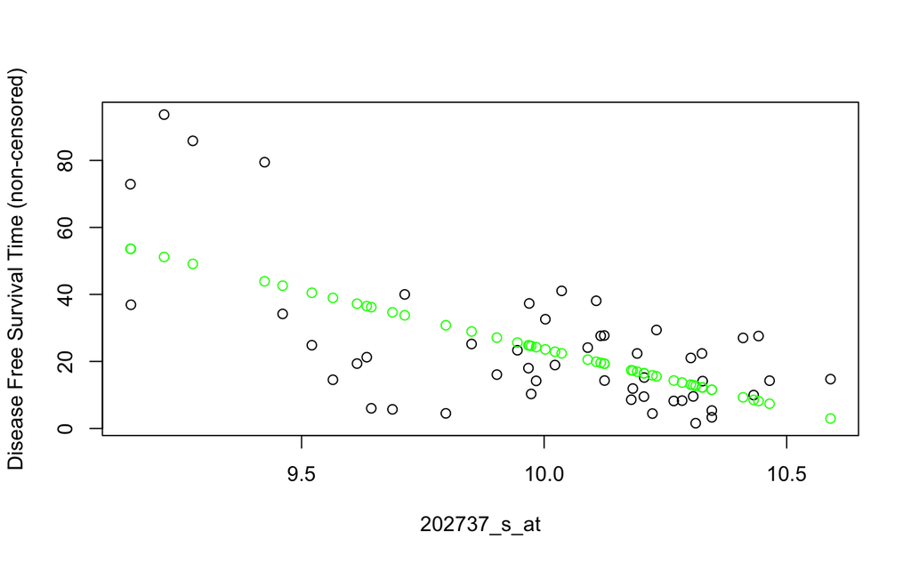

```r
#plot association of 202737_s_at and continuous variable
dfst.202737 <- data.frame(G=eData_filtered["202737_s_at",], DFST=dfs_time)
#plot original data
plot(dfst.202737[,c("G", "DFST")],
     xlab="202737_s_at",
     ylab="Disease Free Survival Time (non-censored)")

#fit model & draw predicted values
lm.202737_s_at <- lm(DFST~G, dfst.202737)
points(dfst.202737$G,
       predict(lm.202737_s_at),
       col="green", pch=1)
```

**DISCUSS**  
So based on the two methods I can see that when using the whole data set the gene with the strongest association is also the gene with the greatest predictor of disease free survival time. I wanted to do this both ways because there could be different outcomes - If a gene had the greatest association (p-value) but not the greatest predictive power (highest r2 value) that would suggest that even though the correlation is statistically significant, the model generated may not explain much of the variance of the the data. This could be due to to outliers or that the relationship isn’t linear even though they’re correlated, for example a monotonic correlation. The fact that 202737_s_at is both the most correlated and the best predictor indicates that the relationship between this gene and disease free survival time is strong and linear.When considering an r-squared value, which ranges from 0-1, this gene is still on the lower side with the model explaining approx 40% of the variability in the data. I interperate this to mean that the gene is informative but there are also other factors influencing disease free survival time, which makes sense as survival time for cancer is a complex variable and I’d expect there would be many factors that contribute to this. Therefore, I believe that a model explaining 40% of variation is meaningful.

The plot shows the observed data points of gene expression versus disease-free survival time, overlaid with the predicted values from the linear model. There is a clear negative association between the variables: as expression of 202737_s_at increases, disease-free survival time decreases. This suggests that higher expression of this gene may be linked to greater cancer severity. The green line represents the best fit from the linear model, while the black circles show the actual data points. Although there is some variability around the fitted line, particularly on the left side, the overall negative trend is evident.

> 3. 50 points Use cross-validation and bootstrap in order to identify the gene with the most significant association with the continuous annotation variable. This was done for cross-validation in the Notes and you are welcome to adapt some of the code to answer this question. Do the same for bootstrap with n=50 simulations. To answer this question, you will need to do the following: For each simulation (50) split the data set into 5 groups for cross validation. Then, for each cross validation group, train a linear model on the training group. from this training group, select the best fit gene and save it to a vector (e.g. called all.best.xval.genes. Next, refit the model on the training data set using the best fit gene, extract the squared errors, and save them to a vector. Finally, return the top 5 genes that are the best fit the most number of times. Repeat this analysis and except instead of running the simulation 50 times, run it 250 times (or more!) and compare the results of the top most frequently identified genes, and the mean squared error estimates using a boxplot. Next, discuss the effect of an outlier in these results, as well as any differences in sample normalization.
- We are combining the cross validation and bootstrapping techniques into one rather than approaching them separately like in the part 1 notes.

**For n=50**

```r
##as function
bootstrap_cross_validation <- function(eData_filtered, dfs_time, n.sims = 50, n.xval=5){
  set.seed(12) #for same results each time
  total.best.genes <- c() #to store across bootstrap cycles
  total.s2 <- list()
  #create design matrix
  dmatrix <- cbind(rep(1, length(dfs_time)), dfs_time)

  #each loop of bootstrap
  for (sim in 1:n.sims){
    #assign samples to groups
    xval.grps <- sample((1:dim(eData_filtered)[2])%%n.xval+1)
    sim.best.genes <- c() #best genes of this round of bootstrap
    sim.s2 <- c() #s2 values for this round of bootstrap

    #loop through each of the 5 cross val groups within each bootstrap cycle
    for (i.xval in 1:n.xval){
      #For training groups - fit linear model:
      exprs.train <- eData_filtered[,xval.grps!=i.xval] #eData of training set
      dmatrix.train <- dmatrix[xval.grps!=i.xval,]
      dfs.fit.train <- lmFit(exprs.train, dmatrix.train)
      #best gene for i.xval-th loop
      best.gene <- rownames(topTable(eBayes(dfs.fit.train), coef = "dfs_time"))[1] #best fit gene
      #add to best genes for this simulation
      sim.best.genes <- c(sim.best.genes, best.gene)


      #use best gene to fit lm on training data
      tmp.df <- data.frame(G=eData_filtered[best.gene,], DFST=dfs_time) #temp data frame for convenience (uses train and test data)
      lm.xval <- lm(DFST~G, tmp.df[xval.grps!=i.xval,]) #use only training data

      #predict values with test group
      test.pred <- predict(lm.xval, tmp.df[xval.grps==i.xval,]) #select rows of tmp.df that are the test group set (current i.xval)
      sim.s2 <- c(sim.s2, (test.pred-tmp.df[xval.grps==i.xval, "DFST"])^2)
    }

    #add this simulations best genes/s2 to final vector/list for entirety of bootstrapping
    total.best.genes <- c(total.best.genes, sim.best.genes)
    total.s2[[sim]] <- sim.s2 #assign the sim.s2 as a list that correlates with the round of bootstrap
  }

  #return total.best.genes and total.s2 as a list so can access each
  list(total.best.genes= total.best.genes, total.s2= total.s2)
}

results.50 <- bootstrap_cross_validation(eData_filtered, dfs_time, n.sims=50)

#Find top 5 genes across all simulations - use table to find counts
n50.genes <- table(results.50$total.best.genes)
n50.top.genes <- sort(n50.genes, decreasing = TRUE)[1:5]
#calculate MSE
#total.s2 is a list containing vectors of sim s2s, calculate the MSE for each sim so we have a range of data to plot
n50.MSE <- sapply(results.50$total.s2, mean) #sapply for lists
```

**For n=300**

```r
#call function with n.sims=300
results.300 <- bootstrap_cross_validation(eData_filtered, dfs_time, n.sims=300)
n300.genes <- table(results.300$total.best.genes)
n300.top.genes <- sort(n300.genes, decreasing = TRUE)[1:5]
n300.MSE <- sapply(results.300$total.s2, mean)
```

```r
#compare n.sims=50 to n.sims=300
cat("Top 5 genes after 50 simulations:\n")
```

```
Top 5 genes after 50 simulations:
```

```r
print(names(n50.top.genes))
```

```
[1] "219532_at"   "235572_at"   "220276_at"   "242434_at"   "202737_s_at"
```

```r
cat("\nCounts:\n")
```

```
Counts:
```

```r
print(n50.top.genes)
```

```
  219532_at   235572_at   220276_at   242434_at 202737_s_at
         28          23          21          20          16
```

```r
cat("\nTop 5 genes after 300 simulations:\n")
```

```
Top 5 genes after 300 simulations:
```

```r
print(names(n300.top.genes))
```

```
[1] "235572_at"   "219532_at"   "220276_at"   "242434_at"   "202737_s_at"
```

```r
cat("\nCounts:\n")
```

```
Counts:
```

```r
print(n300.top.genes)
```

```
  235572_at   219532_at   220276_at   242434_at 202737_s_at
        136         133         117         105          98
```

[figure not shown]

```r
#are top genes the same in each?
top_genes <- unique(c(names(n50.top.genes), names(n300.top.genes)))

# # Normalize by total selections
prop_50 <- freq_50 / (5 * 50)
prop_300 <- freq_300 / (5 * 300)

# Barplot of proportions
barplot(
  rbind(prop_50, prop_300),
  beside = TRUE,
  names.arg = top_genes,
  col = c("blue", "green"),
  legend.text = c("n=50", "n=300"),
  ylab = "Proportion Selected",
  main = "Normalized Top Gene Selection Frequency"
)
```

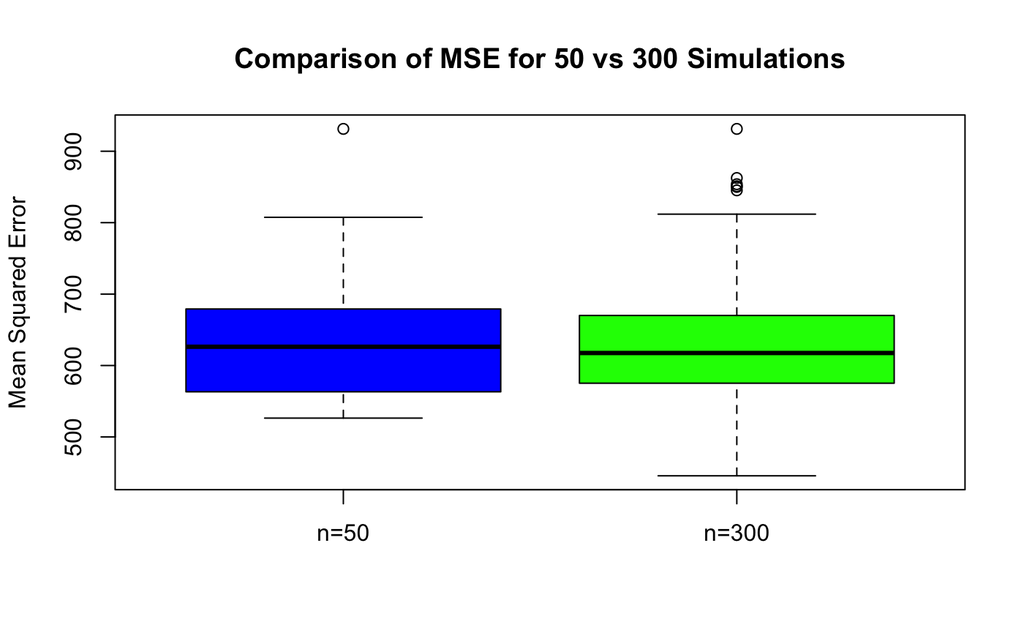

```r
#box plot residuals squared of 50 vs 300 simulation
boxplot(list(`n=50` = n50.MSE, `n=300` = n300.MSE),
        ylab = "Mean Squared Error",
        main = "Comparison of MSE for 50 vs 300 Simulations",
        col = c("blue", "green"))
```

**DISCUSS**

The barplot of selection frequency for the top genes shows how often each gene was picked as the best predictor across all simulations. I normalized the counts so you can directly compare the results from the 50 and 300 simulation runs. The plot shows that some genes are chosen as top predictors pretty consistently, no matter how many simulations are run, which means they have a strong link to the outcome. But for a few genes, the proportion changes when you go from 50 to 300 simulations. This suggests that running more simulations helps to better sort out which genes are truly the most reliable predictors and cuts down on the effect of random chance.